# Question

The graph of $y=f(x)$ is shown below.

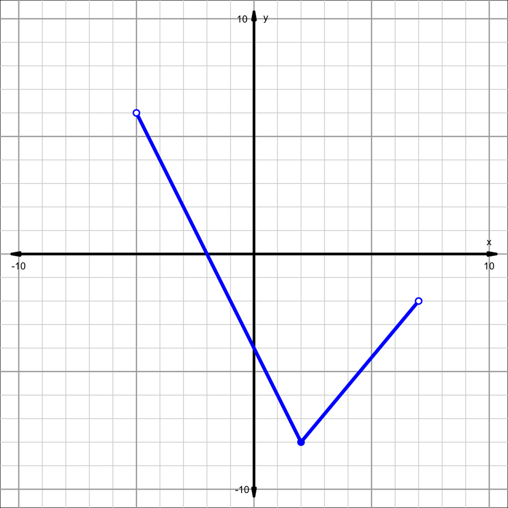

Using interval notation, indicate the following:

1. For what values of $x$ is the function’s output positive? (Where is $f(x)>0$?)
- (##ANSWER1##, ##ANSWER2##)
2. For what values of $x$ is the function’s output negative? (Where is $f(x)<0$?)
- (##ANSWER3##, ##ANSWER4##)
3. For what values of $x$ is the function increasing?
- (##ANSWER5##, ##ANSWER6##)
4. For what values of $x$ is the function decreasing?
- (##ANSWER7##, ##ANSWER8##)
5. What is the domain of $f$? (For what values of $x$ does $f$ exist?)
- (##ANSWER9##, ##ANSWER10##)
6. What is the range of $f$? (For what values of $y$ does $f$ exist?)
- [##ANSWER11##, ##ANSWER12##)

Now, using a [Cartesian coordinate](https://en.wikipedia.org/wiki/Cartesian_coordinate_system), indicate the location of the local minimum.

7. The location of the local minimum is (##ANSWER13##, ##ANSWER14##).

## Answerlist

- -9
- -8
- -7
- -6
- -5
- -4
- -3
- -2
- -1
- 0
- 1
- 2
- 3
- 4
- 5
- 6
- 7
- 8
- 9
- -9
- -8
- -7
- -6
- -5
- -4
- -3
- -2
- -1
- 0
- 1
- 2
- 3
- 4
- 5
- 6
- 7
- 8
- 9
- -9
- -8
- -7
- -6
- -5
- -4
- -3
- -2
- -1
- 0
- 1
- 2
- 3
- 4
- 5
- 6
- 7
- 8
- 9
- -9
- -8
- -7
- -6
- -5
- -4
- -3
- -2
- -1
- 0
- 1
- 2
- 3
- 4
- 5
- 6
- 7
- 8
- 9
- -9
- -8
- -7
- -6
- -5
- -4
- -3
- -2
- -1
- 0
- 1
- 2
- 3
- 4
- 5
- 6
- 7
- 8
- 9
- -9
- -8
- -7
- -6
- -5
- -4
- -3
- -2
- -1
- 0
- 1
- 2
- 3
- 4
- 5
- 6
- 7
- 8
- 9
- -9
- -8
- -7
- -6
- -5
- -4
- -3
- -2
- -1
- 0
- 1
- 2
- 3
- 4
- 5
- 6
- 7
- 8
- 9
- -9
- -8
- -7
- -6
- -5
- -4
- -3
- -2
- -1
- 0
- 1
- 2
- 3
- 4
- 5
- 6
- 7
- 8
- 9
- -9
- -8
- -7
- -6
- -5
- -4
- -3
- -2
- -1
- 0
- 1
- 2
- 3
- 4
- 5
- 6
- 7
- 8
- 9
- -9
- -8
- -7
- -6
- -5
- -4
- -3
- -2
- -1
- 0
- 1
- 2
- 3
- 4
- 5
- 6
- 7
- 8
- 9
- -9
- -8
- -7
- -6
- -5
- -4
- -3
- -2
- -1
- 0
- 1
- 2
- 3
- 4
- 5
- 6
- 7
- 8
- 9
- -9
- -8
- -7
- -6
- -5
- -4
- -3
- -2
- -1
- 0
- 1
- 2
- 3
- 4
- 5
- 6
- 7
- 8
- 9
- -9
- -8
- -7
- -6
- -5
- -4
- -3
- -2
- -1
- 0
- 1
- 2
- 3
- 4
- 5
- 6
- 7
- 8
- 9
- -9
- -8
- -7
- -6
- -5
- -4
- -3
- -2
- -1
- 0
- 1
- 2
- 3
- 4
- 5
- 6
- 7
- 8
- 9

# Solution

1. Interval where $f$ is positive = (-5, -2)
2. Interval where $f$ is negative = (-2, 7)
3. Interval where $f$ is increasing = (2, 7)
4. Interval where $f$ is decreasing = (-5, 2)
5. Domain = (-5, 7)
6. Range = [-8, 6)
7. Point of relative minimum = (2, -8)

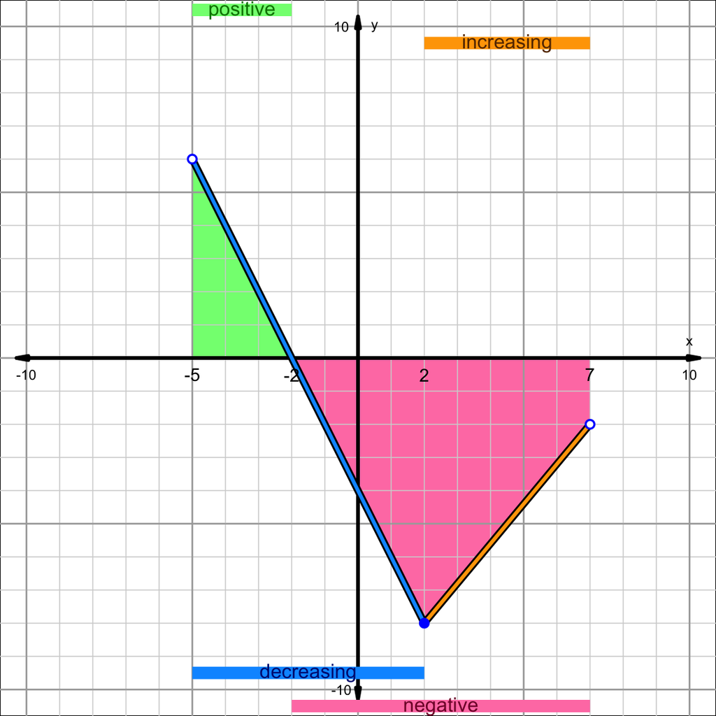

# Meta-information

extype: cloze exclozetype: schoice|schoice|schoice|schoice|schoice|schoice|schoice|schoice|schoice|schoice|schoice|schoice|schoice|schoice exsolution: 0000100000000000000|0000000100000000000|0000000100000000000|0000000000000000100|0000000000010000000|0000000000000000100|0000100000000000000|0000000000010000000|0000100000000000000|0000000000000000100|0100000000000000000|0000000000000001000|0000000000010000000|0100000000000000000 exname: intervals_check